# Parameterised Report with child documents

Mike K Smith

04 January, 2019

# Aims

This report shows how you can use parameters with rmarkdown and knitr to produce reports for multiple outcomes.

## Specifying parameters for knitr / rmarkdown

We’re using a parameter passed into the report via the YAML header. This parameter can be set at time of rendering the report (using the `knit with parameters` option in the RStudio IDE, via “Inputs” specification in RStudio Connect or by specifying the parameters and values within a list passed to the `params` argument of `rmarkdown:render`.

## Quantitative vs non-quantitative view

If the user sets the `quantAudience` parameter to `FALSE` then the code is hidden in the rendered HTML, and certain text sections are hidden. To hide text we keep the relevant text in child documents and only bring these into the report if the `quantAudience` parameter is set to `TRUE`. The code is entirely contained in the parent document, but is executed depending on the setting of the parameter.

## Working with more than one outcome endpoint

The trick is to rename the outcome variables (and potentially associated variables with the same name e.g. HAMDTL17_BASE, HAMDTL17_CHG) to something generic i.e. `outcome` that will allow us to write code once and use it for each of the endpoint variables. We can then use the endpoint parameter `params$endpoint` to specify labels and names wherever these are needed. We could also compute based on the value of `params$endpoint` if we need to do specific things for each endpoint e.g. if one outcome is binary, rather than continuous.

# Data Source

We’re using a publically available dataset on depression.

- The data is from https://missingdata.lshtm.ac.uk/category/dia-working-group/example-data-sets/ (Website accessed 05 June 2018).
- The associated manuscript is https://www.ncbi.nlm.nih.gov/pubmed/15232330.

# Outcomes

There are three outcomes in the dataset:

- HAM-D 17 item rating (`HAMDTL17`)
- Hamilton Anziety Rating Scale (`HAMATOTL`)
- Physician rating of global improvement (`PGIIMP`)

This report summarises HAMDTL17.

# Exploratory data analysis

There are 172 subjects in the dataset. Endpoints are measured on four visits ranging from 4 days to 72 days.

## Summary Statistics

The table below shows mean HAMDTL17 by THERAPY and VISIT.

| THERAPY | VISIT | n | mean | sd | range |
| --- | --- | --- | --- | --- | --- |
| DRUG | 4 | 83 | 16.72289 | 6.396099 | 1 - 30 |
| DRUG | 5 | 76 | 13.90789 | 6.911204 | 0 - 29 |
| DRUG | 6 | 72 | 11.93056 | 7.256520 | 0 - 26 |
| DRUG | 7 | 64 | 10.46875 | 7.219833 | 0 - 30 |
| PLACEBO | 4 | 88 | 15.68182 | 5.440473 | 3 - 27 |
| PLACEBO | 5 | 81 | 14.30864 | 7.098665 | 0 - 34 |
| PLACEBO | 6 | 76 | 12.73684 | 6.986403 | 0 - 29 |
| PLACEBO | 7 | 65 | 12.00000 | 7.830230 | 0 - 33 |

## Visualisation

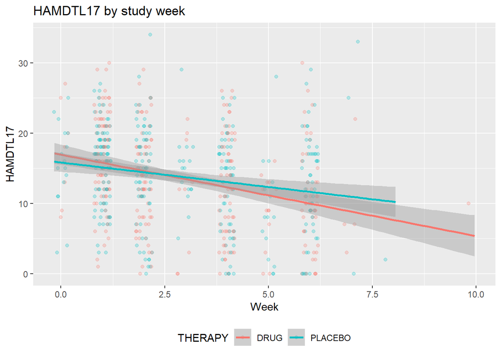

# Analysis

| effect | group | term | estimate | std.error | df | statistic | p.value |
| --- | --- | --- | --- | --- | --- | --- | --- |
| fixed | fixed | (Intercept) | 4.51229921 | 1.20951268 | 432 | 3.7306754 | 2.164464e-04 |
| fixed | fixed | basval | 0.69305539 | 0.06392149 | 169 | 10.8422916 | 3.977165e-21 |
| fixed | fixed | RELDAYS | -0.12351389 | 0.01347909 | 432 | -9.1633705 | 2.047793e-18 |
| fixed | fixed | THERAPYDRUG | -0.62567340 | 0.70433896 | 169 | -0.8883129 | 3.756350e-01 |
| ran_pars | PATIENT | sd_(Intercept) | 3.76515700 | NA | NA | NA | NA |
| ran_pars | PATIENT | cor_RELDAYS.(Intercept) | 0.06235193 | NA | NA | NA | NA |
| ran_pars | PATIENT | sd_RELDAYS | 0.11303102 | NA | NA | NA | NA |
| ran_pars | Residual | sd_Observation | 3.05394627 | NA | NA | NA | NA |

## Model Predictions

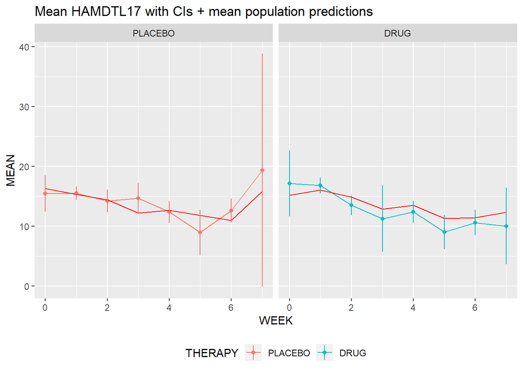

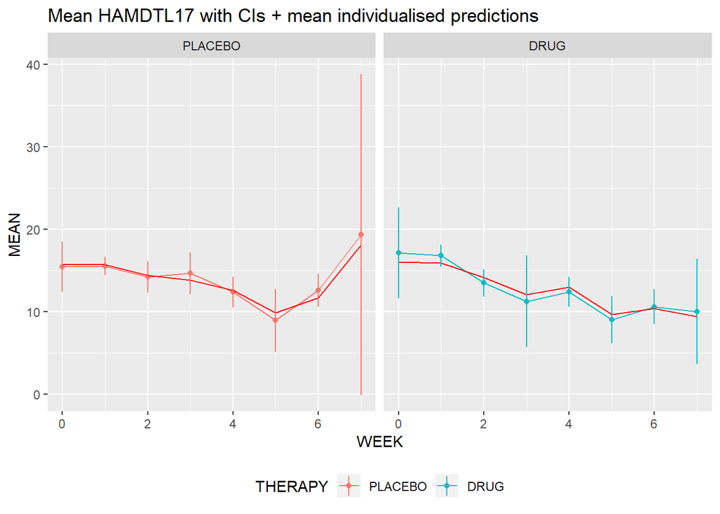